# HW7

Problem 1

a)

since we have A is a constant, $\langle A\rangle = \int A P(x,y) dx dy = A \int P(x,y) dx dy$. Since P(x,y) is the distribution function, we have $ \int P(x,y) dxdy = 1 $. Thus we have $ \langle A\rangle = A \int P(x,y) dx dy = A * 1 = A $

b)

$ {\rm Var}(A) = \int [A - \langle A \rangle] ^2 P(x,y) dxdy = \int [A - A]^2 P(x,y)dxdy = \int 0 P(x,y)dxdy = 0 $

c)

$$ \langle Ax\rangle = \int Ax P(x,y)dxdy = A \int x P(x,y)dxdy = A \langle x\rangle $$

$$ {\rm Var}(Ax) = \int [Ax - \langle Ax \rangle]^2 P(x,y) dxdy = \int [Ax -A\langle x\rangle]^2 P(x,y)dxdy = \int [A(x - \langle x\rangle)]^2 P(x,y)dxdy = \int A^2 [x-\langle x\rangle]^2 P(x,y) dxdy = A^2 \int [x - \langle x\rangle]^2 P(x,y) dxdy = A^2 {\rm Var}(x) $$

Similarly, all these can be applied to ${\rm Var}(By)$, and we can get ${\rm Var}(By) = B^2 {\rm Var}(y)$

d)

$$ \langle Ax + By \rangle = \int (Ax + By) P(x,y) dxdy = \int (Ax)P(x,y) + (By)P(x,y) dxdy = \int (Ax)P(x,y) dxdy + \int (By)P(x,y) dxdy = A \int x P(x,y) dxdy + B \int y P(x,y) dxdy = A \langle x\rangle + B \langle y\rangle $$

e)

$$ \langle x \rangle = \int x P(x,y) dxdy = \int x P(x)P(y) dxdy = \int x P(x) dx * \int P(y) dy = \int x P(x) dx * 1 = \int x P(x) dx $$

Similarly we can probe $ \langle y \rangle = \int y P(y) dy $

f)

$$ {\rm Var}(x) = \int [x - \langle x\rangle]^2 P(x,y) dxdy = \int [x - \langle x\rangle]^2 P(x)P(y) dxdy = \int [x - \langle x\rangle]^2 P(x) dx * \int P(y) dy = \int [x - \langle x\rangle]^2 P(x) dx * 1 = \int [x - \langle x\rangle]^2 P(x) dx $$

Similarly, we can prove $ {\rm Var}(y) = \int [y - \langle y\rangle]^2 P(y) dy $

g)

$$ {\rm Var}(Ax + By) = \int [(Ax + By) - \langle Ax + By\rangle]^2 P(x,y) dxdy = \int [Ax + By - A \langle x \rangle - B \langle y \rangle]^2 P(x,y) dxdy = \int [A(x - \langle x\rangle) + B(y - \langle y\rangle)]^2 P(x,y) dxdy = \int [A(x - \langle x\rangle)]^2 P(x,y) + [B(y - \langle y\rangle)]^2 P(x,y) + 2AB(x - \langle x\rangle)(y - \langle y\rangle) P(x,y) dxdy \\ = \int A^2 [x - \langle x\rangle]^2 P(x,y) dxdy + \int B^2 [y - \langle y\rangle]^2 P(x,y) dxdy + 2AB \int (x - \langle x\rangle)(y - \langle y\rangle) P(x,y) dxdy \\ = A^2 \int [x - \langle x\rangle]^2 P(x) * \int P(y) dy + B^2 \int[y - \langle y\rangle]^2 P(y) dy * \int P(x) dx + 2AB \int (x - \langle x\rangle)P(x)dx * \int (y - \langle y\rangle) P(y) dy\\ = A^2 {\rm Var}(x) * 1 + B^2 {\rm Var}(y) * 1 + 2AB \int (x - \langle x\rangle)P(x)dx * \int (y - \langle y\rangle) P(y) dy $$

since x and y is independed, $ \int (x - \langle x\rangle)P(x)dx * \int (y - \langle y\rangle) P(y) dy $ is 0.

Thus, we can get $ {\rm Var}(Ax + By) = A^2{\rm Var}(x) + B^2{\rm Var}(y) $

Problem 2

a)

we have probobility $$ U(x|a,b) = \begin{cases} \frac{1}{b-a} & \text{for } a \leq x < b, \\ 0 & \text{otherwise}. \end{cases} $$ , the $ \langle x\rangle $ is $ \int x U(x) dx = \int^{b}_{a} \frac{x}{b-a} dx = \frac{b^2-a^2}{2(b-a)} = \frac{a+b}{2} $

b)

```python
import numpy as np
import matplotlib.pyplot as plt
from matplotlib.ticker import AutoMinorLocator
import pandas as pd
import matplotlib.ticker as ticker
import scipy
# import the lib we need later
```

```python
# c)
a = 0
b = 12
# provide a and be as asked

randomnumber = np.random.uniform(a,b,1000000)
# generate the random numbers as asked

print(randomnumber.mean(),np.std(randomnumber))
# print the mean and standard divation from the random number generated

print((a+b)/2,(b-a)/np.sqrt(12))
# print the mean and standard divation from the forumlar
```

```
5.994752497169571 3.464093868334015
6.0 3.464101615137755
```

```python
# d)

sample = np.random.uniform(a,b,(1000000,12))
# generate a sample as asked

mean_of_12 = sample.mean(1)
# calculate the sample of each 12 numbers from a sample

print(mean_of_12.mean(),mean_of_12.std())
# calculate the mean and standard divation of the mean_of_12
```

```
6.001455623866872 1.001180385215327
```

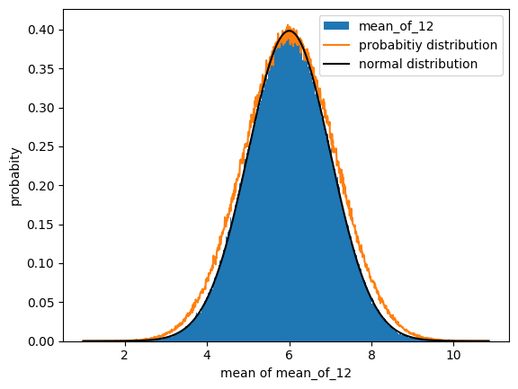

```python
# e)

import scipy.stats


p = plt.hist(mean_of_12,1000,density=True,label='mean_of_12')
# plot the histogram with 1000 bars showing the probobility of having each value as mean over 12 random number

xmin,xmax=plt.xlim()
# get the max and min of the plot

x = np.linspace(xmin,xmax,1000)
# generate x whcih give very point a x

plt.plot(x,p[0],label='probabitiy distribution')
# plot the probabity distribution we get in the plot

n = scipy.stats.norm.pdf(x,mean_of_12.mean(),mean_of_12.std())
# generate the nromal distribution with mean of mean_of_12 and standarddivation of mean_of_12

plt.plot(x,n,label='normal distribution',color = 'black')
# plot the normal distribution

plt.xlabel('mean of mean_of_12')
plt.ylabel('probabity')
plt.legend()
# plot the labels for poeple to read the graph easly
```

f)

since we have a great number of values randomly choose uniformly from 0 to 12. it is obvious that since very number have a equal change to show up, the mean will be the middle point to the unifromaly distribution range, since for every number x smaller than 6, there is a equal chance that a nubmer which is x larger than 6 wiil show up. Thus, the 6 will be the mean.

since every element is choose randomly with unifrom possiblity, we know that the mean of every 12 numbers should be a distribution with center at 6, and the chance of a mean which is very far away from the mean will be very less likely to show up. With this feature, it should be a normal distribution. Since ,the show up of mean is randome, it is reanonalbe to say that it follows tha normal distribution with standard divation 1.